# week 1 - ödev

# week 2 tasks

### TASK-1:

Please write a multiplication function that takes two integers and outputs the product. For instance the output should be as follows for the following x = 2, y = 3: 2 * 3 = 6

```python
def multi_number(x, y):
    print(x," * ",y, " = ",(x*y))

multi_number(3, 5)
```

### TASK-2:

Please write a function that takes an integer and gives the output in relation to the number positive or negative and odd or even. Here is the example: x = 74 The given number, 74, is positive and even.

```python
def odd_even(x):
    if (x%2==0 ):
        print( x,'is even number')
    else:
        print(x,'is odd number')

def positive_negative(x):
    if (x> 0):
        print( x,'is positive number')
    elif(x<0):
        print(x,'is negative number')
    else:
        print(x,'is not positive nor negative number')

def positive_even(x):
    positive_negative(x)
    print("and")
    odd_even(x)

positive_even(-5)
positive_even(341)
positive_even(0)
```

### TASK-3:

Write a Python program to find the numbers which are divisible by 131 or multiple of 53, between 100 and 2700 (both included). Print the numbers on the screen with a space between them

```python
nl = []
for x in range(100, 2700):
    if (x % 131 == 0) or (x % 53 == 0):

        nl.append(str(x))

print(' '.join(nl))
```

### TASK-4:

Write a Python program to get the Tibonacci series between 0 to 50. The Tibonacci Sequence is the series of numbers : 0, 1, 1, 2, 4, 7, 13, 24, 44, .... Every next number is found by adding up the three numbers before it.

```python
x, y, z = 0, 0 ,1
while x < 50:
    print(x)
    x, y,z = y, z,x+y+z
```

### TASK-5:

Write a Python program to check a triangle is equilateral, isosceles or scalene. Note: An equilateral triangle is a triangle in which all three sides are equal. A scalene triangle is a triangle that has three unequal sides. An isosceles triangle is a triangle with (at least) two equal sides.

```python
def check_triangle(x,y,z):
    if(x<=0 or y<=0 or z<=0):
        print("at least one side is negative or zero, enter positive numbers")
    elif (x==y and x==z):
        print("triangle is equilateral")
    elif(x==y or x==z or y==z):
        print("triangle is isosceles")
    else:
        print("triangle is scalene")

check_triangle(1,2,2)
check_triangle(1,1,1)
check_triangle(1,2,0)
```

### extra task

```python
color = {"c1": "Red", "c2": "Green", "c3": "Orange"}
for a in color:
   print(a,":",color[a])
```

# week 3 - Labwork

"""Review of Week-1: on Pythontutor Variables Data types

Review of Week-2: Loops (for & while) Functions

This week: A) Getting input from the user (string, integer, double) B) More complex functions with return values C) Reading and writing into files (excel, txt/csv) D) Regular expressions"""

```python
# GETTING INPUT FROM THE USER (STRING, INTEGER, DOUBLE...)
# We use the input function in Python 3. This function was raw_input() in Python 2.

x1 = float(input("x1: "))
print(x1)
y1 = float(input("y1: "))
print(y1)
```

```
x1: 12
12.0
y1: 23
23.0
```

```python
# MORE COMPLEX FUNCTIONS & THE USE OF RETURN VALUES

def average(x, y):
 return (x + y)/2
print(average(4, 3))
```

```
3.5
```

### TASK-1:

Find the slope of the line between 2 given points. Write two functions for this that will print and return the values respectively.

```python
def slope_print(x1, y1 ,x2 ,y2):
 print((y2 - y1)/(x2 - x1))

slope_print(4, 3, 2, 1)
```

```python
# Now, please return it
def slope_return(x1, y1 ,x2 ,y2):
 return ((y2 - y1)/(x2 - x1))

slope_return(4, 3, 2, 1)
```

```python
import math
p1 = [4, 0]
p2 = [6, 6]
distance = math.sqrt( ((p1[0]-p2[0])**2)+((p1[1]-p2[1])**2) )
print(distance)
```

```
6.324555320336759
```

### TASK-2:

Please write the following calculation as a function and return the calculated value (distance) instead of printing it. Please get the input from the user while doing this calculation.

```python
def cal_dist(a = float(input("p1[0]: ")),b= float(input("p1[1]: ")),
             c= float(input("p2[0]: ")),d = float(input("p2[1]: "))):
    distance = math.sqrt(((a - c) ** 2) + (b - d) ** 2)
    return distance

print(cal_dist())
```

```
p1[0]: 12
p1[1]: 23
p2[0]: 12
p2[1]: 23
0.0
```

### TASK-3: Find the Max of three numbers.

# def max_of_two( x, y ): if x > y: return x return y

# def max_of_three( x, y, z ): return max_of_two( x, max_of_two( y, z ) ) print(max_of_three(3, 6, -5)

```python
def two_max(x, y):
    if(x>y):
        return x
    else:
        return y

def three_max(x, y, z):
    return two_max(two_max(x, y), z)

print(three_max(2, 3, 5))

print(three_max(3, 6, 5))
```

```python
# Write a Python function to create and print a list where the values are
# square of numbers between 1 and 20 (both included).
def printValues():
    l = list()
    for i in range(1, 21):
        l.append(i ** 2)
    print(l)

printValues()

# https://www.w3resource.com/python-exercises/python-functions-exercise-1.php
# https://www.w3resource.com/python-exercises/python-functions-exercise-2.php
# https://www.w3resource.com/python-exercises/python-functions-exercise-16.php
# READING THE FILES AND WRITING INTO THEM
# Here is the sample file: text.txt
```

```
[1, 4, 9, 16, 25, 36, 49, 64, 81, 100, 121, 144, 169, 196, 225, 256, 289, 324, 361, 400]
```

"""What is Python language? Python is a widely used high-level, general-purpose, interpreted, dynamic programming language.Its design philosophy emphasizes code readability , and its syntax allows programmers to express concepts in fewer lines of code than possible in languages such as C++ or Java. Python supports multiple programming paradigms, including object-oriented, imperative and functional programming or procedural styles. It features a dynamic type system and automatic memory management and has a large and comprehensive standard library. The best way we learn anything is by practice and exercise questions. We have started this section for those (beginner to intermediate) who are familiar with Python."""

```python
# check whether a file exists.

import os.path
open('BDA507-Labwork-W3.txt')
print(os.path.isfile('BDA507-Labwork-W3.txt'))

# FILE I/O
def file_read(fname):
    txt = open(fname)
    print(txt.readline())

file_read('BDA507-Labwork-W3.txt')
```

[output not shown]

```python
# READING FIRST N LINES OF A FILE

def file_read_from_head(fname, nlines):
    from itertools import islice
    with open(fname) as f:
        for line in islice(f, nlines):
            print(line)
file_read_from_head('BDA507-Labwork-W3.txt',2)
```

[output not shown]

```python
def file_read(fname):
    from itertools import islice
    with open(fname, "w") as myfile:
        myfile.write("Python Exercises\n")
        myfile.write("Java Exercises")
    txt = open(fname)
    print(txt.read())
file_read('BDA507-Labwork-W3.txt')
```

```python
# Read a file line by line and store it into a list.

def file_read(fname):
    with open(fname) as f:
        #Content_list is the list that contains the read lines.
        content_list = f.readlines()
        print(content_list)
file_read('BDA507-Labwork-W3.txt')
```

```python
# Read a file line by line store it into a variable.

def file_read(fname):
    with open (fname, "r") as myfile:
        data=myfile.readlines()
        print(data)
file_read('BDA507-Labwork-W3.txt')
```

```python
# Please count the number of lines in a text file.

def file_lengthy(fname):
    with open(fname) as f:
        for i, l in enumerate(f):
            pass
    return i + 1
print("Number of lines in the file: ",file_lengthy("BDA507-Labwork-W3.txt"))
```

```python
# Please count the frequency of words in a file.

from collections import Counter
def word_count(fname):
        with open(fname) as f:
                return Counter(f.read().split())
print("Number of words in the file :", word_count("deneme2.txt"))
```

```python
# Write a Python program to write a list content to a file.

color = ['Red', 'Green', 'White', 'Black', 'Pink', 'Yellow']
with open('abc.txt', "w") as myfile:
        for c in color:
                myfile.write("%s\n" % c)
content = open('abc.txt')
print(content.read())
```

```python
# PYTHON REGULAR EXPRESSIONS
# https://www.w3resource.com/python-exercises/re/index.php

# Check that a string contains only a certain set of characters (in this case a-z, A-Z and 0-9)
import re
def is_allowed_specific_char(string):
    charRe = re.compile(r'[^a-zA-Z0-9.]')
    string = charRe.search(string)
    return not bool(string)
print(is_allowed_specific_char("ABCDEFabcdef123450"))
print(is_allowed_specific_char("*&%@#!}{"))
```

```python
# Check if a given string that has an a followed by zero or more b's. 'ab*?'
# What about a given string that has an a followed by one or more b's? We use this: 'ab+?'
# What about a given string that has an a followed by zero or only one b? We use this: 'ab??'
# What about a given string that has an a followed by 3 b's? We use curly brackets and put the relevant number inside the parentheses: 'ab{3}?'
# What about a a given string that has an a followed by 2 to 3 b's? We use curly brackets and put the relevant number inside the parentheses: 'ab{2,3}?'
# What about an 'a' followed by anything, ending in 'b'. We use this expression 'a.*?b$'

import re
def text_match(text):
        patterns = 'ab?c'
        if re.search(patterns,  text):
                return 'Found a match!'
        else:
                return('Not matched!')

print(text_match("ac"))
print(text_match("abc"))
print(text_match("abbc"))
```

```python
# Find the following strings:
# matches a word at the beginning of a string.'^\w+'
# matches a word at the end of a string. '\w+\S*$'
# matches a word at end of string, with optional punctuation. '\w+\S*$'
# matches a word containing 'z'. '\w*z.\w*'
# matches a word containing 'z', not start or end of the word. '\Bz\B'
# match a string that contains only upper and lowercase letters, numbers, and underscores. '^[a-zA-Z0-9_]*$'

import re
def text_match(text):
        patterns = '^\w+'
        if re.search(patterns,  text):
                return 'Found a match!'
        else:
                return('Not matched!')

print(text_match("The quick brown fox jumps over the lazy dog."))
print(text_match(" The quick brown fox jumps over the lazy dog."))
```

```python
# Check whether a string will start with a specific number. "^5"
# Check for a number at the end of a string. ".*[0-9]$"

import re
def match_num(string):
    text = re.compile(r"^5")
    if text.match(string):
        return True
    else:
        return False
print(match_num('5-2345861'))
print(match_num('6-2345861'))
```

```python
# Replace whitespaces with an underscore and vice versa.

import re
text = 'Python Exercises'
text =text.replace (" ", "_")
print(text)
text =text.replace ("_", " ")
print(text)
```

```python
# Extract year, month and date from an url.

import re
def extract_date(url):
    return re.findall(r'/(\d{4})/(\d{1,2})/(\d{1,2})/', url)
url1= "https://www.washingtonpost.com/news/football-insider/wp/2016/09/02/odell-beckhams-fame-rests-on-one-stupid-little-ball-josh-norman-tells-author/"
print(extract_date(url1))
```

```python
# Convert a date of yyyy-mm-dd format to dd-mm-yyyy format.

import re
def change_date_format(dt):
        return re.sub(r'(\d{4})-(\d{1,2})-(\d{1,2})', '\\3-\\2-\\1', dt)
dt1 = "2026-01-02"
print("Original date in YYY-MM-DD Format: ",dt1)
print("New date in DD-MM-YYYY Format: ",change_date_format(dt1))
```

```python
# Now let's learn how to plot figures in python
# Please draw a line with suitable label in the x axis, y axis and a title.

import matplotlib.pyplot as plt
X = range(1, 50)
Y = [value * 3 for value in X]
print("Values of X:")
print(*range(1,50))
print("Values of Y (thrice of X):")
print(Y)
# Plot lines and/or markers to the Axes.
plt.plot(X, Y)
# Set the x axis label of the current axis.
plt.xlabel('x - axis')
# Set the y axis label of the current axis.
plt.ylabel('y - axis')
# Set a title
plt.title('Draw a line.')
# Display the figure.
plt.show()
```

```python
# Please draw a line using given axis values with suitable label in the x axis , y axis and a title.

import matplotlib.pyplot as plt
# x axis values
x = [1,2,3]
# y axis values
y = [2,4,1]
# Plot lines and/or markers to the Axes.
plt.plot(x, y)
# Set the x axis label of the current axis.
plt.xlabel('x - axis')
# Set the y axis label of the current axis.
plt.ylabel('y - axis')
# Set a title
plt.title('Sample graph!')
# Display a figure.
plt.show()
```

```python
# Please draw a line using given axis values with suitable label in the x axis , y axis and a title from the given file:
# testplot.txt

import matplotlib.pyplot as plt
with open("testplot.txt") as f:
    data = f.read()
data = data.split('\n')
x = [row.split(' ')[0] for row in data]
y = [row.split(' ')[1] for row in data]
plt.plot(x, y)
# Set the x axis label of the current axis.
plt.xlabel('x - axis')
# Set the y axis label of the current axis.
plt.ylabel('y - axis')
# Set a title
plt.title('Sample graph!')
# Display a figure.
plt.show()
```

```python
# Please draw line charts of the financial data of Alphabet Inc. between October 3, 2016 to October 7, 2016.
# The sample financial data is in fdata.csv:

import matplotlib.pyplot as plt
import pandas as pd
df = pd.read_csv('fdata.csv', index_col=0)
df.plot(x=df.index, y=df.columns)
plt.show()
```

```python
# Please plot two or more lines on same plot with suitable legends of each line.

import matplotlib.pyplot as plt
# line 1 points
x1 = [10,20,30]
y1 = [20,40,10]
# plotting the line 1 points
plt.plot(x1, y1, label = "line 1")
# line 2 points
x2 = [10,20,30]
y2 = [40,10,30]
# plotting the line 2 points
plt.plot(x2, y2, label = "line 2")
plt.xlabel('x - axis')
# Set the y axis label of the current axis.
plt.ylabel('y - axis')
# Set a title of the current axes.
plt.title('Two or more lines on same plot with suitable legends ')
# show a legend on the plot
plt.legend()
# Display a figure.
plt.show()
```

```python
# Please plot two or more lines with legends, different widths and colors.

import matplotlib.pyplot as plt
# line 1 points
x1 = [10,20,30]
y1 = [20,40,10]
# line 2 points
x2 = [10,20,30]
y2 = [40,10,30]
# Set the x axis label of the current axis.
plt.xlabel('x - axis')
# Set the y axis label of the current axis.
plt.ylabel('y - axis')
# Set a title
plt.title('Two or more lines with different widths and colors with suitable legends ')
# Display the figure.
plt.plot(x1, y1, color='blue', linewidth=3, label='line1-width-3')
plt.plot(x2, y2, color='red', linewidth=5, label='line2-width-5')
# show a legend on the plot
plt.legend()
plt.show()
```

# week 3 - Assignment

### Question 1

```python
def maxOfThreeNum (num1, num2, num3):
    if(num1 > num2):
        if(num1>num3):
            return num1
        return num3
    elif(num2>num3):
        return num2
    return num3


print(maxOfThreeNum (4, 7, 5))

print(maxOfThreeNum (9, 7, 5))

print(maxOfThreeNum (4, 7, 11))
```

```
7
9
11
```

### Question 2

```python
import math
def cal_area(ax = float(input("a(x): ")), ay = float(input("a(y): ")),
             bx = float(input("b(x): ")), by = float(input("b(y): ")),
             cx = float(input("c(x): ")), cy = float(input("c(y): "))
            ):
    x = math.sqrt(((ax-bx) ** 2)+((ay-by) ** 2))
    y = math.sqrt(((cx-bx) ** 2)+((cy-by) ** 2))
    z = math.sqrt(((ax-cx) ** 2)+((ay-cy) ** 2))
    s = (x + y + z) / 2
    area = math.sqrt(s * (s - x) * (s - y) * (s - z))
    return area


print(cal_area())
```

### question 3

```python
color = ['One', 'Two', 'Three', 'Four', 'Five', 'Six']

f= open("color.txt","w+")


f = open('color.txt', 'r+')
f.truncate()

# sort color list
color_sorted=sorted(color)

# write n a text
with open('color.txt', "w") as myfile:
        for c in color_sorted:
                myfile.write("%s\n" % c)
content = open('color.txt')
print(content.read())
```

```
Five
Four
One
Six
Three
Two
```

### question 4

```python
def is_there(x):
    if(x in 'AAACACCCCBAAAAACBBBBABBCCCABAAABBAAAAAAAAAABBBBBAAABCCCACCCCBBBBBAAA') :
        return True
    return False


print(is_there('CCBBBBBAAA'))
print(is_there('CCBBBBBAABA'))
```

### question 5

```python
from itertools import islice
BMI_Data = []
with open('/Users/yetkineser/Desktop/mef Python/diğer bilgisayar/BMI_data.txt') as f:
    x=1
    for line in islice(f,20):
        if x > 1:
            arr = line.split('\t')
            Height = float(arr[4])
            Weight = float(arr[5])
            BMI = Weight / Height * Height
            BMI = [arr[0], arr[1] ,arr[2], arr[3], arr[4], arr[5], BMI]      #vector
            BMI_Data.append(BMI)
        x = x + 1


print(BMI_Data)
```

[output not shown]

# week 4 - labwork

```python
import numpy as np

x = np.arange(5, 126, 5).reshape(5,5)

print(x)
print(x[2][2])
print(x[2,2])
print(x[2,3])
```

```
[[  5  10  15  20  25]
 [ 30  35  40  45  50]
 [ 55  60  65  70  75]
 [ 80  85  90  95 100]
 [105 110 115 120 125]]
65
65
70
```

```python
i = 0
j = 0
while(i < 5 ):
    while(j < 5):
        print(x[i][j],end=" ")
        j+=1
    j=0
    i+=1
```

```
5 10 15 20 25 30 35 40 45 50 55 60 65 70 75 80 85 90 95 100 105 110 115 120 125
```

```python
for i in range(5):
    for j in range(5):
        print(x[j,i],end=" ")
```

```
5 30 55 80 105 10 35 60 85 110 15 40 65 90 115 20 45 70 95 120 25 50 75 100 125
```

```python
i = 0
j = 0
while(i < 5 ):
    while(j < 5):
        if x[i,j]%2==0:
            print(0,end=" ")
        else:
            print(-1,end=" ")
        j+=1
    j=0
    i+=1
```

```
-1 0 -1 0 -1 0 -1 0 -1 0 -1 0 -1 0 -1 0 -1 0 -1 0 -1 0 -1 0 -1
```

```python
# Write a Python program to save a NumPy array to a text file.
import numpy as np
a = np.arange(1.0, 2.0, 0.2)
np.savetxt('file.out', a, delimiter=',')

print(a)
```

```
[ 1.   1.2  1.4  1.6  1.8]
```

```python
import numpy as np
import pandas as pd
import os

titanic_train = pd.read_csv('/Users/yetkineser/Desktop/mef Python/diger bilgisayar/train.csv')

titanic_test = pd.read_csv('/Users/yetkineser/Desktop/mef Python/diger bilgisayar/test.csv')

titanic_train.dtypes

print(titanic_train.head(5))

titanic_train.describe()

titanic_train.head(5)
titanic_train.describe()


# In[66]:


titanic_train[categorical].describe()
```

```
   PassengerId  Survived  Pclass  \
0            1         0       3
1            2         1       1
2            3         1       3
3            4         1       1
4            5         0       3

                                                Name     Sex   Age  SibSp  \
0                            Braund, Mr. Owen Harris    male  22.0      1
1  Cumings, Mrs. John Bradley (Florence Briggs Th...  female  38.0      1
2                             Heikkinen, Miss. Laina  female  26.0      0
3       Futrelle, Mrs. Jacques Heath (Lily May Peel)  female  35.0      1
4                           Allen, Mr. William Henry    male  35.0      0

   Parch            Ticket     Fare Cabin Embarked
0      0         A/5 21171   7.2500   NaN        S
1      0          PC 17599  71.2833   C85        C
2      0  STON/O2. 3101282   7.9250   NaN        S
3      0            113803  53.1000  C123        S
4      0            373450   8.0500   NaN        S
```

[output not shown]

```python
# In[87]:


titanic_train.Survived=titanic_train.Survived.astype(str)
titanic_train.head(5)
```

[output not shown]

```python
titanic_train.dtypes
```

```
PassengerId      int64
Survived        object
Pclass           int64
Name            object
Sex             object
Age            float64
SibSp            int64
Parch            int64
Ticket          object
Fare           float64
Cabin           object
Embarked        object
dtype: object
```

```python
index = np.where(titanic_train["Survived"]=="1")
titanic_train["Survived"].loc[index]="Y"
index = np.where(titanic_train["Survived"]=="0")
titanic_train["Survived"].loc[index]="N"
titanic_train.head(5)
```

|  | PassengerId | Survived | Pclass | Name | Sex | Age | SibSp | Parch | Ticket | Fare | Cabin | Embarked |
| --- | --- | --- | --- | --- | --- | --- | --- | --- | --- | --- | --- | --- |
| 0 | 1 | N | 3 | Braund, Mr. Owen Harris | male | 22.0 | 1 | 0 | A/5 21171 | 7.2500 | NaN | S |
| 1 | 2 | Y | 1 | Cumings, Mrs. John Bradley (Florence Briggs Th... | female | 38.0 | 1 | 0 | PC 17599 | 71.2833 | C85 | C |
| 2 | 3 | Y | 3 | Heikkinen, Miss. Laina | female | 26.0 | 0 | 0 | STON/O2. 3101282 | 7.9250 | NaN | S |
| 3 | 4 | Y | 1 | Futrelle, Mrs. Jacques Heath (Lily May Peel) | female | 35.0 | 1 | 0 | 113803 | 53.1000 | C123 | S |
| 4 | 5 | N | 3 | Allen, Mr. William Henry | male | 35.0 | 0 | 0 | 373450 | 8.0500 | NaN | S |

```python
titanic_train["Cabin"].describe()
```

```
count     204
unique    147
top        G6
freq        4
Name: Cabin, dtype: object
```

```python
char_cabin = titanic_train["Cabin"].astype(str) # Convert data to str
new_Cabin = np.array([cabin[0] for cabin in char_cabin]) # Take first letter
index = np.where(new_Cabin!="n")
new_Cabin = new_Cabin[index]
new_Cabin = pd.Categorical(new_Cabin)
new_Cabin .describe()
```

| categories | counts | freqs |
| --- | --- | --- |
| A | 15 | 0.073529 |
| B | 47 | 0.230392 |
| C | 59 | 0.289216 |
| D | 33 | 0.161765 |
| E | 32 | 0.156863 |
| F | 13 | 0.063725 |
| G | 4 | 0.019608 |
| T | 1 | 0.004902 |

# week 4 - ASSİGNMENT

### Question 1

```python
import numpy as np

# it can be two row
x = np.arange(9, 101, 7).reshape(2,7)

print(x)

# if you want three row, it can be

y = np.arange(9, 150, 7).reshape(3,7)

print(y)

x1 = x % 8
y1 = y % 8

print(x1)
print(y1)
```

### Question 2

```python
x = np.zeros(49)
x = x.reshape(7,7)
x = x + 9

print(x)

# First Method(Part A)

x[1:-1,1:-1] = 7
x[0,] = 8
x[:,-1] = 8
x[:,0] = 8
x[-1,] = 8

print(x)

# Second Method(Part B)

x = np.zeros(49)
x = x.reshape(7,7)
x = x + 9

print(x)


i = 0
j = 0
while(i < 7 ):
    while(j < 7):
        if((i == 0) | (j == 0) | (i == 6) | (j == 6)):
            x[i][j] = 8
        else:
            x[i][j] = 7
        j += 1
    j = 0
    i += 1

print(x)
```

```
[[ 9.  9.  9.  9.  9.  9.  9.]
 [ 9.  9.  9.  9.  9.  9.  9.]
 [ 9.  9.  9.  9.  9.  9.  9.]
 [ 9.  9.  9.  9.  9.  9.  9.]
 [ 9.  9.  9.  9.  9.  9.  9.]
 [ 9.  9.  9.  9.  9.  9.  9.]
 [ 9.  9.  9.  9.  9.  9.  9.]]
[[ 8.  8.  8.  8.  8.  8.  8.]
 [ 8.  7.  7.  7.  7.  7.  8.]
 [ 8.  7.  7.  7.  7.  7.  8.]
 [ 8.  7.  7.  7.  7.  7.  8.]
 [ 8.  7.  7.  7.  7.  7.  8.]
 [ 8.  7.  7.  7.  7.  7.  8.]
 [ 8.  8.  8.  8.  8.  8.  8.]]
[[ 9.  9.  9.  9.  9.  9.  9.]
 [ 9.  9.  9.  9.  9.  9.  9.]
 [ 9.  9.  9.  9.  9.  9.  9.]
 [ 9.  9.  9.  9.  9.  9.  9.]
 [ 9.  9.  9.  9.  9.  9.  9.]
 [ 9.  9.  9.  9.  9.  9.  9.]
 [ 9.  9.  9.  9.  9.  9.  9.]]
[[ 8.  8.  8.  8.  8.  8.  8.]
 [ 8.  7.  7.  7.  7.  7.  8.]
 [ 8.  7.  7.  7.  7.  7.  8.]
 [ 8.  7.  7.  7.  7.  7.  8.]
 [ 8.  7.  7.  7.  7.  7.  8.]
 [ 8.  7.  7.  7.  7.  7.  8.]
 [ 8.  8.  8.  8.  8.  8.  8.]]
```

### Question 3

```python
# in class
print ("Checkerboard pattern:")
x = np.zeros((8,8),dtype=int)
x [1: : 2, : : 2] = 1
x [: : 2, 1 : : 2] = 1
print(x)

# homework
print ("Checkerboard pattern:")
x = np.zeros((8,8),dtype=int)
x [0: : 2, : : 2] = 1
x [: : 2, 0 : : 2] = 1
print(x)
```

### Question 4

```
(418, 11)
   PassengerId  Pclass                                          Name     Sex  \
0          892       3                              Kelly, Mr. James    male
1          893       3              Wilkes, Mrs. James (Ellen Needs)  female
2          894       2                     Myles, Mr. Thomas Francis    male
3          895       3                              Wirz, Mr. Albert    male
4          896       3  Hirvonen, Mrs. Alexander (Helga E Lindqvist)  female
5          897       3                    Svensson, Mr. Johan Cervin    male
6          898       3                          Connolly, Miss. Kate  female
7          899       2                  Caldwell, Mr. Albert Francis    male
8          900       3     Abrahim, Mrs. Joseph (Sophie Halaut Easu)  female
9          901       3                       Davies, Mr. John Samuel    male

    Age  SibSp  Parch     Ticket     Fare Cabin Embarked
0  34.5      0      0     330911   7.8292   NaN        Q
1  47.0      1      0     363272   7.0000   NaN        S
2  62.0      0      0     240276   9.6875   NaN        Q
3  27.0      0      0     315154   8.6625   NaN        S
4  22.0      1      1    3101298  12.2875   NaN        S
5  14.0      0      0       7538   9.2250   NaN        S
6  30.0      0      0     330972   7.6292   NaN        Q
7  26.0      1      1     248738  29.0000   NaN        S
8  18.0      0      0       2657   7.2292   NaN        C
9  21.0      2      0  A/4 48871  24.1500   NaN        S
       PassengerId      Pclass         Age       SibSp       Parch        Fare
count   418.000000  418.000000  332.000000  418.000000  418.000000  417.000000
mean   1100.500000    2.265550   30.272590    0.447368    0.392344   35.627188
std     120.810458    0.841838   14.181209    0.896760    0.981429   55.907576
min     892.000000    1.000000    0.170000    0.000000    0.000000    0.000000
25%     996.250000    1.000000   21.000000    0.000000    0.000000    7.895800
50%    1100.500000    3.000000   27.000000    0.000000    0.000000   14.454200
75%    1204.750000    3.000000   39.000000    1.000000    0.000000   31.500000
max    1309.000000    3.000000   76.000000    8.000000    9.000000  512.329200
                            Name   Sex    Ticket            Cabin Embarked
count                        418   418       418               91      418
unique                       418     2       363               76        3
top     Willard, Miss. Constance  male  PC 17608  B57 B59 B63 B66        S
freq                           1   266         5                3      270
   PassengerId Survived  Pclass  \
0            1       no       3
1            2      yes       1
2            3      yes       3
3            4      yes       1
4            5       no       3

                                                Name     Sex   Age  SibSp  \
0                            Braund, Mr. Owen Harris    male  22.0      1
1  Cumings, Mrs. John Bradley (Florence Briggs Th...  female  38.0      1
2                             Heikkinen, Miss. Laina  female  26.0      0
3       Futrelle, Mrs. Jacques Heath (Lily May Peel)  female  35.0      1
4                           Allen, Mr. William Henry    male  35.0      0

   Parch            Ticket     Fare Cabin Embarked
0      0         A/5 21171   7.2500   NaN        S
1      0          PC 17599  71.2833   C85        C
2      0  STON/O2. 3101282   7.9250   NaN        S
3      0            113803  53.1000  C123        S
4      0            373450   8.0500   NaN        S
77
```

[output not shown]

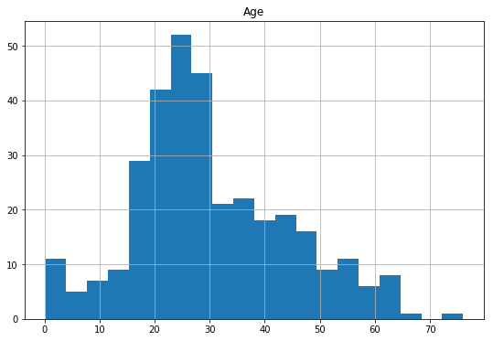

```python
import numpy as np
import pandas as pd
import os

import matplotlib.pyplot as plt
%matplotlib inline
import warnings
warnings.filterwarnings('ignore')

# a
titanic_test = pd.read_csv('/Users/yetkineser/Desktop/mef Python/diger bilgisayar/test.csv')

# b
print(titanic_test.shape)

# c
print(titanic_test.head(10))

# d
print(titanic_test.describe())

categorical = titanic_test.dtypes[titanic_test.dtypes == "object"].index

print(titanic_test[categorical].describe())

# e
# there is no survived column in test data
titanic_train = pd.read_csv('/Users/yetkineser/Desktop/mef Python/diger bilgisayar/train.csv')

titanic_train.Survived=titanic_train.Survived.astype(str)
index = np.where(titanic_train["Survived"]=="1")
titanic_train["Survived"].loc[index]="yes"
index = np.where(titanic_train["Survived"]=="0")
titanic_train["Survived"].loc[index]="no"

print(titanic_train.head())

# f

# g

index = np.where(titanic_test["Age"] > 40 )

k = titanic_test.loc[index]

print(len(k))

# h

missing = np.where(titanic_test["Age"].isnull() == True)

len(missing[0])




# In[110]:


import matplotlib.pyplot as plt

titanic_test.hist(column='Age',    # Column to plot
                   figsize=(9,6),   # Plot size
                   bins=20).plt.show()        # Number of histogram bins

titanic_train["Fare"].plt.show(kind="box",
                           figsize=(9,9))


titanic_train["Fare"].plot(kind="box",
                           figsize=(9,9))
```